# Tune and interpret decision trees for wind turbines

Nguyen_LSCM

11/1/2020

**Tune and interpret decision trees for wind turbines**

This is the latest in my series of screencasts demonstrating how to use the tidymodels packages, from starting out with first modeling steps to tuning more complex models. Today’s screencast walks through how to tune, fit and predict from decision tree models, using this week’s dataset on Canadian wind turbines

Here is the code I used in the video, for those who prefer reading instead of or in addition to video.

# Explore data

Our modeling goal is to predict the capacity of wind turbines in Canada based on other characteristics of the turbines fro mthis week Simon Couch outlined this week how to use stacks for ensembling with this dataset, but here let’s take a more straighforward approach.

Let’s start by reading in the data

```r
library(tidyverse)
turbines <- read_csv("https://raw.githubusercontent.com/rfordatascience/tidytuesday/master/data/2020/2020-10-27/wind-turbine.csv")
turbines
```

```
## # A tibble: 6,698 x 15
##    objectid province_territ~ project_name total_project_c~ turbine_identif~
##       <dbl> <chr>            <chr>                   <dbl> <chr>
##  1        1 Alberta          Optimist Wi~             0.9  OWE1
##  2        2 Alberta          Castle Rive~            44    CRW1
##  3        3 Alberta          Waterton Wi~             3.78 WWT1
##  4        4 Alberta          Waterton Wi~             3.78 WWT2
##  5        5 Alberta          Waterton Wi~             3.78 WWT3
##  6        6 Alberta          Waterton Wi~             3.78 WWT4
##  7        7 Alberta          Cowley North            19.5  CON1
##  8        8 Alberta          Cowley North            19.5  CON2
##  9        9 Alberta          Cowley North            19.5  CON3
## 10       10 Alberta          Cowley North            19.5  CON4
## # ... with 6,688 more rows, and 10 more variables:
## #   turbine_number_in_project <chr>, turbine_rated_capacity_k_w <dbl>,
## #   rotor_diameter_m <dbl>, hub_height_m <dbl>, manufacturer <chr>,
## #   model <chr>, commissioning_date <chr>, latitude <dbl>, longitude <dbl>,
## #   notes <chr>
```

How is the capacity related to other characteristics like the year of commissioning or size of the turbines?

```r
turbines_df <- turbines %>%
               transmute(
                              turbine_capacity = turbine_rated_capacity_k_w,
                              rotor_diameter_m,
                              hub_height_m,
                              commissioning_date = parse_number(commissioning_date),
                              province_territory = fct_lump_n(province_territory, 10),
                              model = fct_lump_n(model, 10)
               ) %>%
               filter(!is.na(turbine_capacity)) %>%
               mutate_if(is.character, factor)
```

How is the capacity related to other characteristics like the year of commissioning or size of the turbines?

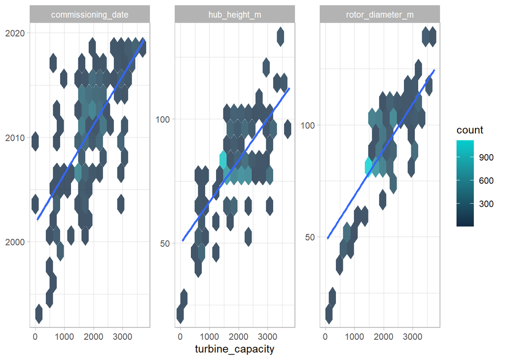

```r
theme_set(theme_light())

turbines_df %>%
               select(turbine_capacity:commissioning_date) %>%
               pivot_longer(rotor_diameter_m:commissioning_date)%>%
               ggplot(aes(turbine_capacity, value)) +
               geom_hex(bins = 15, alpha = 0.8) +
               geom_smooth(method = 'lm') +
               facet_wrap(~name, scales = 'free_y')+
               labs(y = NULL) +
               scale_fill_gradient(high = 'cyan3')
```

These relationships are the kind that we want to use in modeling, whether that’s the modeling stacking Simon demonstrated or the single model we’ll use here.

# Build a model

We can start by loading the tidymodels metapackage, splitting our data into training and testing sets, and creating cross-validation samples

```r
library(tidymodels)
set.seed(123)
wind_split <- initial_split(turbines_df, strata = turbine_capacity)

wind_train <- training(wind_split)
wind_test <- testing(wind_split)

set.seed(234)
wind_folds <- vfold_cv(wind_train, strata = turbine_capacity)

wind_folds
```

```
## #  10-fold cross-validation using stratification
## # A tibble: 10 x 2
##    splits             id
##    <list>             <chr>
##  1 <split [4.4K/488]> Fold01
##  2 <split [4.4K/487]> Fold02
##  3 <split [4.4K/486]> Fold03
##  4 <split [4.4K/486]> Fold04
##  5 <split [4.4K/486]> Fold05
##  6 <split [4.4K/486]> Fold06
##  7 <split [4.4K/486]> Fold07
##  8 <split [4.4K/486]> Fold08
##  9 <split [4.4K/485]> Fold09
## 10 <split [4.4K/484]> Fold10
```

Next, let’s create a tunable decision tree model specification

```r
tree_spec <- decision_tree(
               cost_complexity = tune(),
               tree_depth = tune(),
               min_n = tune()
) %>%
               set_engine('rpart') %>%
               set_mode('regression')

tree_spec
```

```
## Decision Tree Model Specification (regression)
##
## Main Arguments:
##   cost_complexity = tune()
##   tree_depth = tune()
##   min_n = tune()
##
## Computational engine: rpart
```

We need a set of possible parameter values to try out for the decision tree

```r
tree_grid <- grid_regular(cost_complexity(), tree_depth(), min_n(), levels = 4)

tree_grid
```

```
## # A tibble: 64 x 3
##    cost_complexity tree_depth min_n
##              <dbl>      <int> <int>
##  1    0.0000000001          1     2
##  2    0.0000001             1     2
##  3    0.0001                1     2
##  4    0.1                   1     2
##  5    0.0000000001          5     2
##  6    0.0000001             5     2
##  7    0.0001                5     2
##  8    0.1                   5     2
##  9    0.0000000001         10     2
## 10    0.0000001            10     2
## # ... with 54 more rows
```

Now, let’s try out all the possible parameter values on all our resampled datasets. Let’s use some non-default metrics, while we;re at it

```r
doParallel::registerDoParallel()

set.seed(345)

tree_rs <- tune_grid(
               tree_spec,
               turbine_capacity ~.,
               resamples = wind_folds,
               grid = tree_grid,
               metrics = metric_set(rmse, rsq, mae, mape)
)

tree_rs
```

```
## # Tuning results
## # 10-fold cross-validation using stratification
## # A tibble: 10 x 4
##    splits             id     .metrics           .notes
##    <list>             <chr>  <list>             <list>
##  1 <split [4.4K/488]> Fold01 <tibble [256 x 7]> <tibble [0 x 1]>
##  2 <split [4.4K/487]> Fold02 <tibble [256 x 7]> <tibble [0 x 1]>
##  3 <split [4.4K/486]> Fold03 <tibble [256 x 7]> <tibble [0 x 1]>
##  4 <split [4.4K/486]> Fold04 <tibble [256 x 7]> <tibble [0 x 1]>
##  5 <split [4.4K/486]> Fold05 <tibble [256 x 7]> <tibble [0 x 1]>
##  6 <split [4.4K/486]> Fold06 <tibble [256 x 7]> <tibble [0 x 1]>
##  7 <split [4.4K/486]> Fold07 <tibble [256 x 7]> <tibble [0 x 1]>
##  8 <split [4.4K/486]> Fold08 <tibble [256 x 7]> <tibble [0 x 1]>
##  9 <split [4.4K/485]> Fold09 <tibble [256 x 7]> <tibble [0 x 1]>
## 10 <split [4.4K/484]> Fold10 <tibble [256 x 7]> <tibble [0 x 1]>
```

Notice that we aren;t tuning a `workflow()` here, as I have often shown how to do instead we are tuning the model specification (accompanied by a formula preprocessor); this is so we can use the bare model in some model evaluation activities.

# Evaluate model

Now let’s check out how we did. We can collect or visualize the metrics

```r
collect_metrics(tree_rs)
```

```
## # A tibble: 256 x 9
##    cost_complexity tree_depth min_n .metric .estimator    mean     n std_err
##              <dbl>      <int> <int> <chr>   <chr>        <dbl> <int>   <dbl>
##  1    0.0000000001          1     2 mae     standard   386.       10  1.50
##  2    0.0000000001          1     2 mape    standard    27.7      10  1.30
##  3    0.0000000001          1     2 rmse    standard   508.       10  1.44
##  4    0.0000000001          1     2 rsq     standard     0.303    10  0.0134
##  5    0.0000001             1     2 mae     standard   386.       10  1.50
##  6    0.0000001             1     2 mape    standard    27.7      10  1.30
##  7    0.0000001             1     2 rmse    standard   508.       10  1.44
##  8    0.0000001             1     2 rsq     standard     0.303    10  0.0134
##  9    0.0001                1     2 mae     standard   386.       10  1.50
## 10    0.0001                1     2 mape    standard    27.7      10  1.30
## # ... with 246 more rows, and 1 more variable: .config <chr>
```

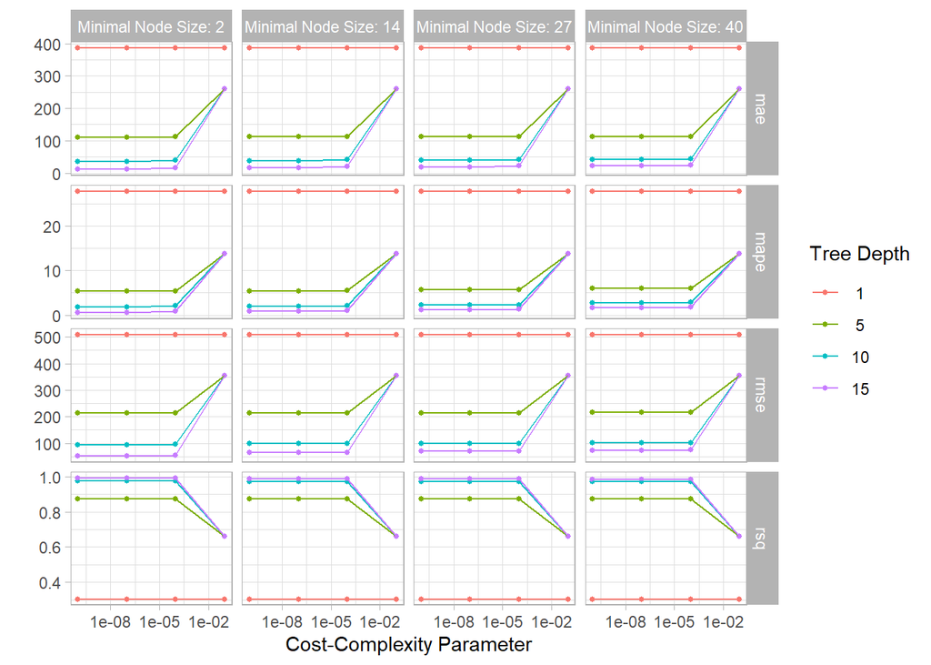

```r
autoplot(tree_rs) + theme_light(base_family = 'IBMPlexSans')
```

Looks like this data need a fairly complex tree

We can examine or select the best sets of parameter options, chosen by whichever metric we want

```r
show_best(tree_rs, 'mape')
```

```
## # A tibble: 5 x 9
##   cost_complexity tree_depth min_n .metric .estimator  mean     n std_err
##             <dbl>      <int> <int> <chr>   <chr>      <dbl> <int>   <dbl>
## 1    0.0000000001         15     2 mape    standard   0.564    10  0.0592
## 2    0.0000001            15     2 mape    standard   0.564    10  0.0591
## 3    0.0000000001         15    14 mape    standard   0.823    10  0.0547
## 4    0.0000001            15    14 mape    standard   0.823    10  0.0547
## 5    0.0001               15     2 mape    standard   0.885    10  0.0705
## # ... with 1 more variable: .config <chr>
```

```r
show_best(tree_rs, 'rmse')
```

```
## # A tibble: 5 x 9
##   cost_complexity tree_depth min_n .metric .estimator  mean     n std_err
##             <dbl>      <int> <int> <chr>   <chr>      <dbl> <int>   <dbl>
## 1    0.0000000001         15     2 rmse    standard    52.4    10    5.08
## 2    0.0000001            15     2 rmse    standard    52.4    10    5.09
## 3    0.0001               15     2 rmse    standard    55.6    10    4.64
## 4    0.0000000001         15    14 rmse    standard    64.7    10    4.59
## 5    0.0000001            15    14 rmse    standard    64.7    10    4.59
## # ... with 1 more variable: .config <chr>
```

Next, let’s use one of these ‘best’ sets of parameters to update and finalize our model.

```r
final_tree <- finalize_model(tree_spec, select_best(tree_rs, 'rmse'))

final_tree
```

```
## Decision Tree Model Specification (regression)
##
## Main Arguments:
##   cost_complexity = 1e-10
##   tree_depth = 15
##   min_n = 2
##
## Computational engine: rpart
```

This model `final_tree` is updated and finalized (no longer tunable) but it is not fit. It has all its hyperparameters set but it has not been fit to any data. We have a couple of options for how to fit this model. We ca neither fit `final_tree` to training data using `fit()` or to the testing/ training splot using `last_fit()`, which will give us some other results along with the fitted output.

```r
final_fit <- fit(final_tree, turbine_capacity ~., wind_train)

final_rs <- last_fit(final_tree, turbine_capacity~., wind_split)
```

We can predict from either one of these objects

```r
predict(final_fit, wind_train[144, ])
```

```
## # A tibble: 1 x 1
##   .pred
##   <dbl>
## 1  1800
```

What are the most important variables in this decision tree for predicting turbine capacity?

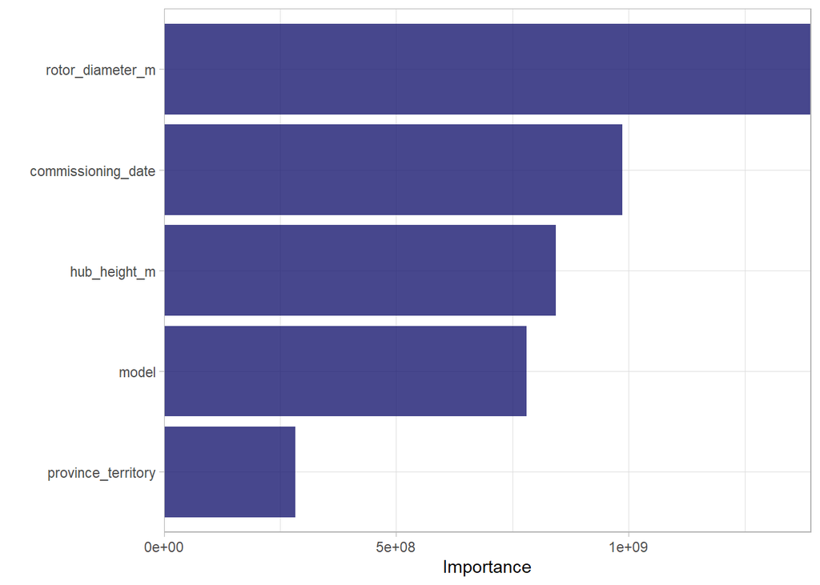

```r
library(vip)
final_fit %>%
               vip(geom = 'col',  aesthetics = list(fill = 'midnightblue', alpha = 0.8)) +
               scale_y_continuous(expand = c(0, 0))
```

I really like the `parttree` package for visualization decision tree results. It only works for models with one or two predictors, so we’ll have to fit an example model that isn’t quite the same as our full model. It can still help us understand how this decision tree is working, but keep in mind that is it not the same as our full model with more predictors

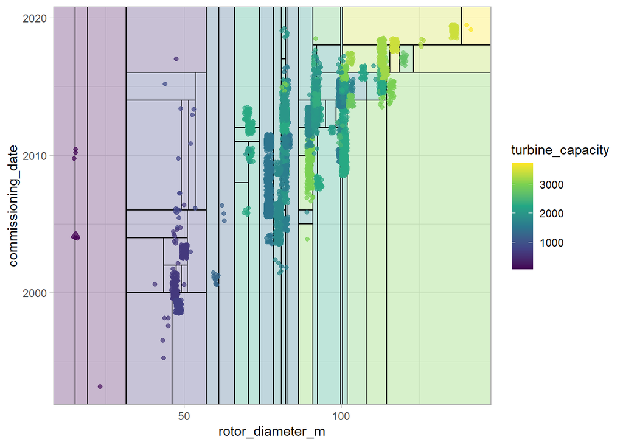

```r
library(parttree)

ex_fit <- fit(
               final_tree,
               turbine_capacity ~ rotor_diameter_m + commissioning_date, wind_train)

wind_train %>%
               ggplot(aes(rotor_diameter_m, commissioning_date)) +
               geom_parttree(data = ex_fit, aes(fill = turbine_capacity), alpha = 0.3)+
               geom_jitter(alpha = 0.7, width =1, height = 0.5, aes(color = turbine_capacity)) +
               scale_colour_viridis_c(aesthetics = c('color', 'fill'))
```

Finally, let’s turn to the testing data! These results are stored in final_rs, along with the fitted output there. We can see both metrics on the testing data and predictions.

```r
collect_metrics(final_rs)
```

```
## # A tibble: 2 x 3
##   .metric .estimator .estimate
##   <chr>   <chr>          <dbl>
## 1 rmse    standard      73.6
## 2 rsq     standard       0.985
```

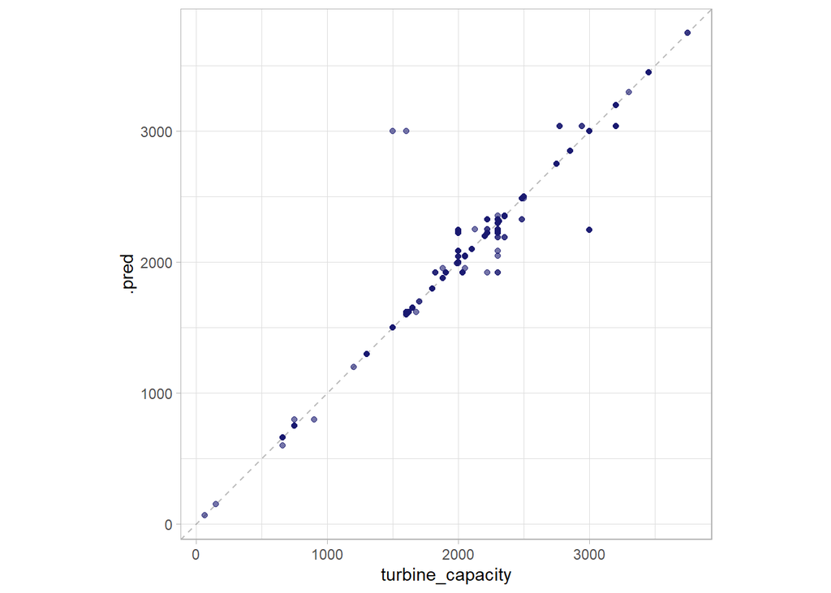

```r
final_rs %>%
               collect_predictions() %>%
               ggplot(aes(turbine_capacity, .pred)) +
               geom_abline(slope = 1, lty = 2, color = 'gray50', alpha = 0.5) +
               geom_point(alpha = 0.6, color = 'midnightblue') +
               coord_fixed()
```